# CL_ECE5332_Report3

Caleb Leonard

October 12, 2025

## Defect Detection

### Retrospective Analysis

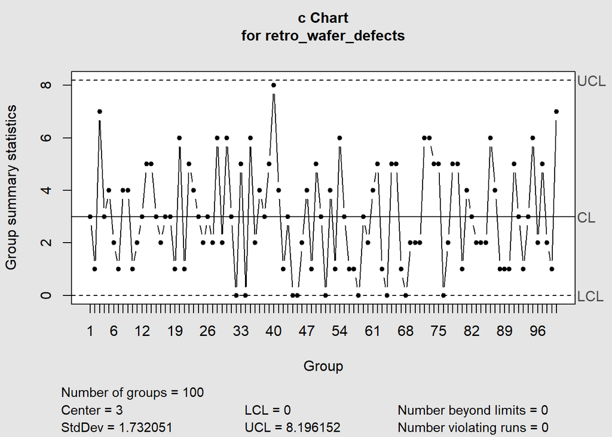

```
## List of 11
##  $ call      : language qcc(data = retro_wafer_defects, type = "c", sizes = length(retro_wafer_defects))
##  $ type      : chr "c"
##  $ data.name : chr "retro_wafer_defects"
##  $ data      : int [1:100, 1] 3 1 7 3 4 2 1 4 4 1 ...
##   ..- attr(*, "dimnames")=List of 2
##  $ statistics: Named int [1:100] 3 1 7 3 4 2 1 4 4 1 ...
##   ..- attr(*, "names")= chr [1:100] "1" "2" "3" "4" ...
##  $ sizes     : int [1:100] 1 1 1 1 1 1 1 1 1 1 ...
##  $ center    : num 3
##  $ std.dev   : num 1.73
##  $ nsigmas   : num 3
##  $ limits    : num [1, 1:2] 0 8.2
##   ..- attr(*, "dimnames")=List of 2
##  $ violations:List of 2
##  - attr(*, "class")= chr "qcc"
```

```r
retro_wafer_defects<-read.csv("https://raw.githubusercontent.com/Caleb-Leonard/Statistical-Methods-in-Semiconductor-Manufacturing/refs/heads/main/wafer_defect_retrospective.csv", header=FALSE)

qcc(data=retro_wafer_defects,sizes= length(retro_wafer_defects),type="c") #initial C control chart trial
```

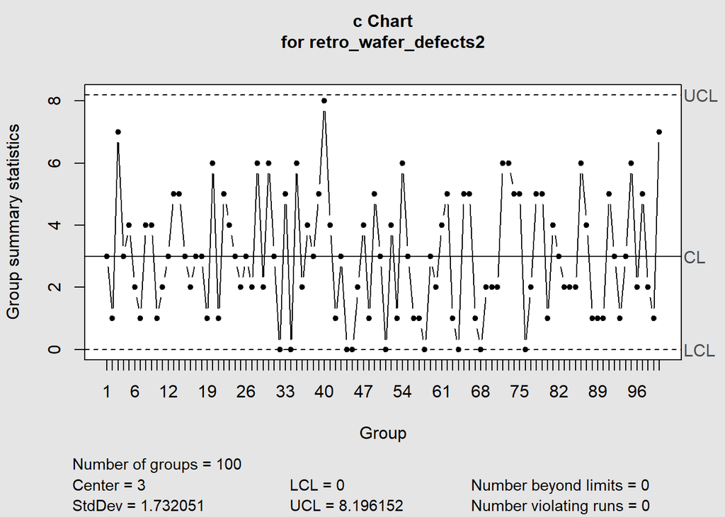

```
## List of 11
##  $ call      : language qcc(data = retro_wafer_defects2, type = "c", sizes = length(retro_wafer_defects2))
##  $ type      : chr "c"
##  $ data.name : chr "retro_wafer_defects2"
##  $ data      : int [1:100, 1] 3 1 7 3 4 2 1 4 4 1 ...
##   ..- attr(*, "dimnames")=List of 2
##  $ statistics: Named int [1:100] 3 1 7 3 4 2 1 4 4 1 ...
##   ..- attr(*, "names")= chr [1:100] "1" "2" "3" "4" ...
##  $ sizes     : int [1:100] 100 100 100 100 100 100 100 100 100 100 ...
##  $ center    : num 3
##  $ std.dev   : num 1.73
##  $ nsigmas   : num 3
##  $ limits    : num [1, 1:2] 0 8.2
##   ..- attr(*, "dimnames")=List of 2
##  $ violations:List of 2
##  - attr(*, "class")= chr "qcc"
```

```r
retro_wafer_defects2<-retro_wafer_defects[retro_wafer_defects<=8.196152 & retro_wafer_defects>=0] #remove datapoints outside control limits

qcc(data=retro_wafer_defects2,sizes=length(retro_wafer_defects2),type="c") #second trial
```

There were no groups in the retrospective wafer defect detection that were outside of the control limits, nor were there any violating runs. There were a few groups to watch for as they were close to being out of limits as well as having 0 defects. There were no groups removed as they were all within the control limits.

### Online Analysis

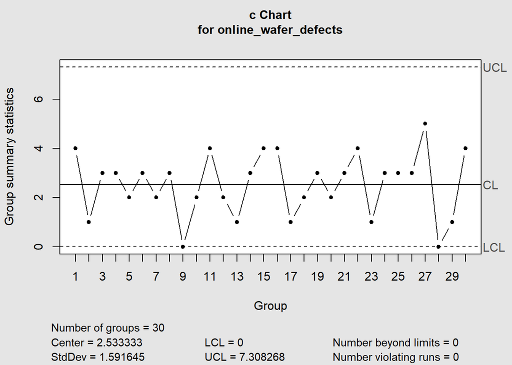

```
## List of 11
##  $ call      : language qcc(data = online_wafer_defects, type = "c", sizes = 30)
##  $ type      : chr "c"
##  $ data.name : chr "online_wafer_defects"
##  $ data      : int [1:30, 1] 4 1 3 3 2 3 2 3 0 2 ...
##   ..- attr(*, "dimnames")=List of 2
##  $ statistics: Named int [1:30] 4 1 3 3 2 3 2 3 0 2 ...
##   ..- attr(*, "names")= chr [1:30] "1" "2" "3" "4" ...
##  $ sizes     : num [1:30] 30 30 30 30 30 30 30 30 30 30 ...
##  $ center    : num 2.53
##  $ std.dev   : num 1.59
##  $ nsigmas   : num 3
##  $ limits    : num [1, 1:2] 0 7.31
##   ..- attr(*, "dimnames")=List of 2
##  $ violations:List of 2
##  - attr(*, "class")= chr "qcc"
```

```r
online_wafer_defects<-read.csv("https://raw.githubusercontent.com/Caleb-Leonard/Statistical-Methods-in-Semiconductor-Manufacturing/refs/heads/main/wafer_defect_online.csv", header=FALSE)

qcc(data=online_wafer_defects,sizes=30,type="c") #standalone online C chart
```

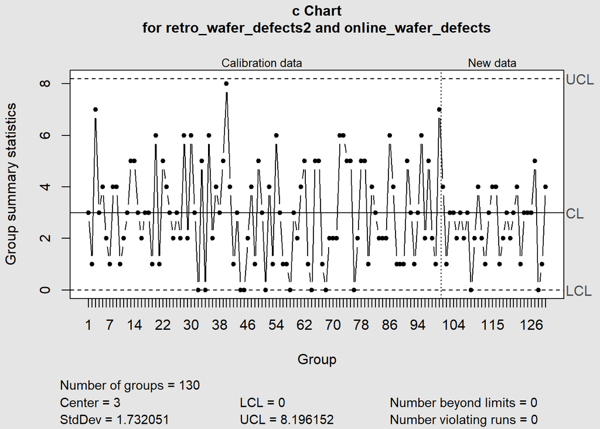

```
## List of 15
##  $ call        : language qcc(data = retro_wafer_defects2, type = "c", sizes = length(retro_wafer_defects2),      newdata = online_wafer_defects)
##  $ type        : chr "c"
##  $ data.name   : chr "retro_wafer_defects2"
##  $ data        : int [1:100, 1] 3 1 7 3 4 2 1 4 4 1 ...
##   ..- attr(*, "dimnames")=List of 2
##  $ statistics  : Named int [1:100] 3 1 7 3 4 2 1 4 4 1 ...
##   ..- attr(*, "names")= chr [1:100] "1" "2" "3" "4" ...
##  $ sizes       : int [1:100] 100 100 100 100 100 100 100 100 100 100 ...
##  $ center      : num 3
##  $ std.dev     : num 1.73
##  $ newstats    : Named int [1:30] 4 1 3 3 2 3 2 3 0 2 ...
##   ..- attr(*, "names")= chr [1:30] "101" "102" "103" "104" ...
##  $ newdata     : int [1:30, 1] 4 1 3 3 2 3 2 3 0 2 ...
##   ..- attr(*, "dimnames")=List of 2
##  $ newsizes    : int [1:30] 1 1 1 1 1 1 1 1 1 1 ...
##  $ newdata.name: chr "online_wafer_defects"
##  $ nsigmas     : num 3
##  $ limits      : num [1, 1:2] 0 8.2
##   ..- attr(*, "dimnames")=List of 2
##  $ violations  :List of 2
##  - attr(*, "class")= chr "qcc"
```

```r
qcc(data=retro_wafer_defects2,sizes=length(retro_wafer_defects2),type="c", newdata = online_wafer_defects) #C chart with restrospective data as calibration with online data as new data
```

A standalone C chart with online defect detection data was used to understand the data without comparing to the retrospective defect detection data. Then, the online defect detection data was compared to respective data control limits, where there were less overall defects.

## Semiconductor Testing

### Retrospective Analysis

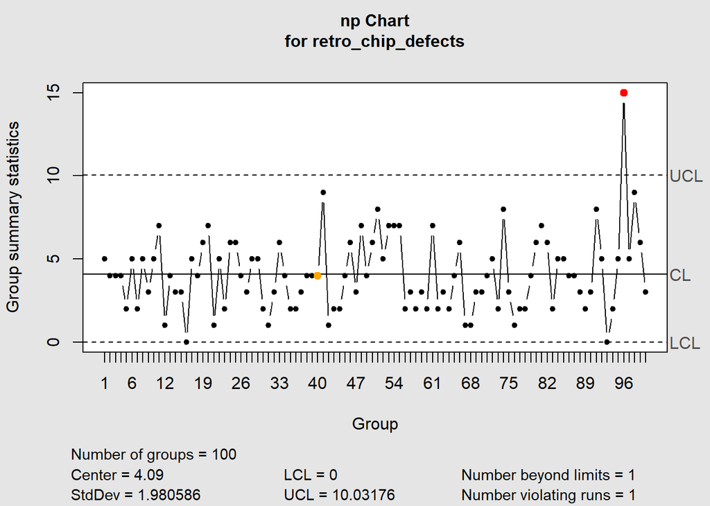

```
## List of 11
##  $ call      : language qcc(data = retro_chip_defects, type = "np", sizes = 100)
##  $ type      : chr "np"
##  $ data.name : chr "retro_chip_defects"
##  $ data      : int [1:100, 1] 5 4 4 4 2 5 2 5 3 5 ...
##   ..- attr(*, "dimnames")=List of 2
##  $ statistics: Named int [1:100] 5 4 4 4 2 5 2 5 3 5 ...
##   ..- attr(*, "names")= chr [1:100] "1" "2" "3" "4" ...
##  $ sizes     : num [1:100] 100 100 100 100 100 100 100 100 100 100 ...
##  $ center    : num 4.09
##  $ std.dev   : num 1.98
##  $ nsigmas   : num 3
##  $ limits    : num [1, 1:2] 0 10
##   ..- attr(*, "dimnames")=List of 2
##  $ violations:List of 2
##  - attr(*, "class")= chr "qcc"
```

```r
retro_chip_defects<-read.csv("https://raw.githubusercontent.com/Caleb-Leonard/Statistical-Methods-in-Semiconductor-Manufacturing/refs/heads/main/retrospective_semiconductor_np_chart.csv",
header=FALSE)

qcc(data=retro_chip_defects,sizes=100,type="np") #Initial NP chart
```

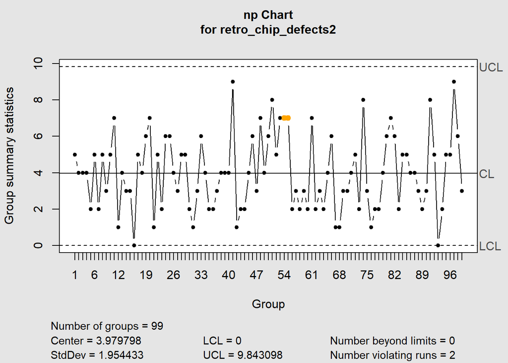

```
## List of 11
##  $ call      : language qcc(data = retro_chip_defects2, type = "np", sizes = length(retro_chip_defects2))
##  $ type      : chr "np"
##  $ data.name : chr "retro_chip_defects2"
##  $ data      : int [1:99, 1] 5 4 4 4 2 5 2 5 3 5 ...
##   ..- attr(*, "dimnames")=List of 2
##  $ statistics: Named int [1:99] 5 4 4 4 2 5 2 5 3 5 ...
##   ..- attr(*, "names")= chr [1:99] "1" "2" "3" "4" ...
##  $ sizes     : int [1:99] 99 99 99 99 99 99 99 99 99 99 ...
##  $ center    : num 3.98
##  $ std.dev   : num 1.95
##  $ nsigmas   : num 3
##  $ limits    : num [1, 1:2] 0 9.84
##   ..- attr(*, "dimnames")=List of 2
##  $ violations:List of 2
##  - attr(*, "class")= chr "qcc"
```

```r
retro_chip_defects2<-retro_chip_defects[retro_chip_defects<=10.03176 & retro_chip_defects>=0] #remove datapoints outside control limits

qcc(data=retro_chip_defects2,sizes=length(retro_chip_defects2),type="np") #second trial
```

On the inital NP control chart, there was one group out of control. This group was removed and the control chart and its statistics were recalculated.

### Online Analysis

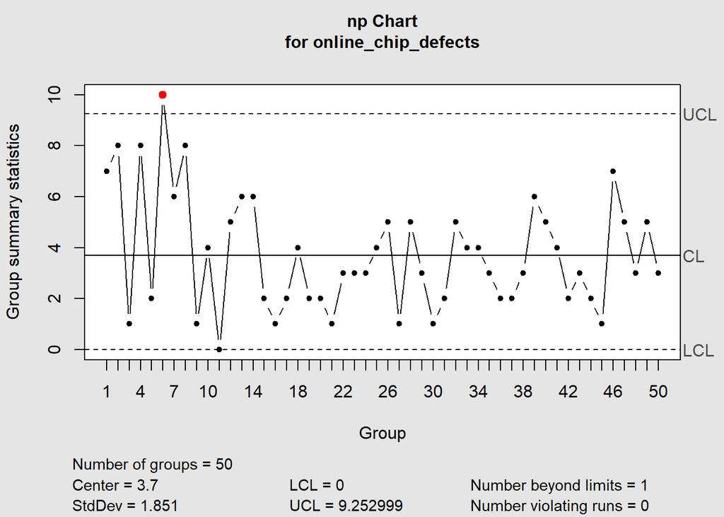

```
## List of 11
##  $ call      : language qcc(data = online_chip_defects, type = "np", sizes = 50)
##  $ type      : chr "np"
##  $ data.name : chr "online_chip_defects"
##  $ data      : int [1:50, 1] 7 8 1 8 2 10 6 8 1 4 ...
##   ..- attr(*, "dimnames")=List of 2
##  $ statistics: Named int [1:50] 7 8 1 8 2 10 6 8 1 4 ...
##   ..- attr(*, "names")= chr [1:50] "1" "2" "3" "4" ...
##  $ sizes     : num [1:50] 50 50 50 50 50 50 50 50 50 50 ...
##  $ center    : num 3.7
##  $ std.dev   : num 1.85
##  $ nsigmas   : num 3
##  $ limits    : num [1, 1:2] 0 9.25
##   ..- attr(*, "dimnames")=List of 2
##  $ violations:List of 2
##  - attr(*, "class")= chr "qcc"
```

```r
online_chip_defects<-read.csv("https://raw.githubusercontent.com/Caleb-Leonard/Statistical-Methods-in-Semiconductor-Manufacturing/refs/heads/main/online_monitoring_semiconductor_np_chart.csv", header=FALSE)

qcc(data=online_chip_defects,sizes=50,type="np") #standalone online NP chart
```

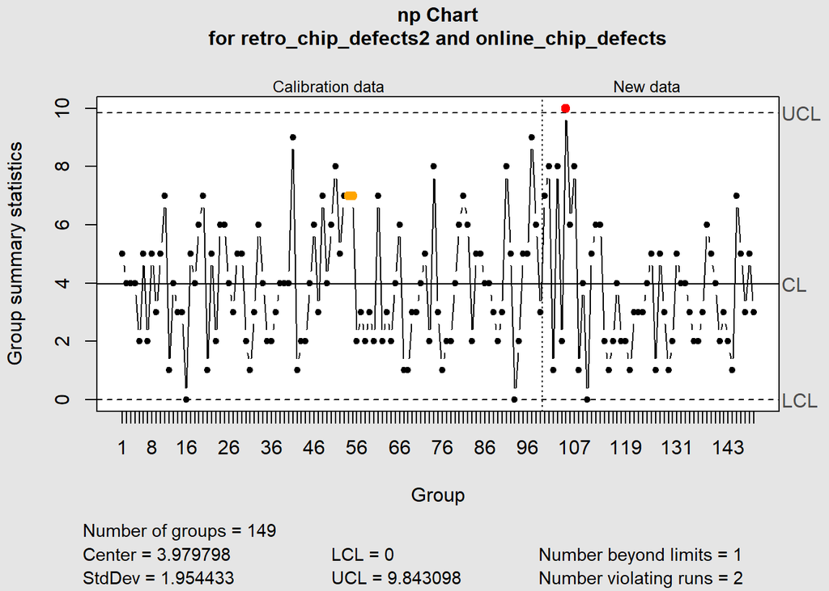

```
## List of 15
##  $ call        : language qcc(data = retro_chip_defects2, type = "np", sizes = length(retro_chip_defects2),      limits = c(0, 9.843098), n| __truncated__ ...
##  $ type        : chr "np"
##  $ data.name   : chr "retro_chip_defects2"
##  $ data        : int [1:99, 1] 5 4 4 4 2 5 2 5 3 5 ...
##   ..- attr(*, "dimnames")=List of 2
##  $ statistics  : Named int [1:99] 5 4 4 4 2 5 2 5 3 5 ...
##   ..- attr(*, "names")= chr [1:99] "1" "2" "3" "4" ...
##  $ sizes       : int [1:99] 99 99 99 99 99 99 99 99 99 99 ...
##  $ center      : num 3.98
##  $ std.dev     : num 1.95
##  $ newstats    : Named int [1:50] 7 8 1 8 2 10 6 8 1 4 ...
##   ..- attr(*, "names")= chr [1:50] "100" "101" "102" "103" ...
##  $ newdata     : int [1:50, 1] 7 8 1 8 2 10 6 8 1 4 ...
##   ..- attr(*, "dimnames")=List of 2
##  $ newsizes    : int [1:50] 1 1 1 1 1 1 1 1 1 1 ...
##  $ newdata.name: chr "online_chip_defects"
##  $ nsigmas     : num 3
##  $ limits      : num [1, 1:2] 0 9.84
##   ..- attr(*, "dimnames")=List of 2
##  $ violations  :List of 2
##  - attr(*, "class")= chr "qcc"
```

```r
qcc(data=retro_chip_defects2,sizes=length(retro_chip_defects2),type="np", newdata = online_chip_defects, newsizes = length(online_chip_defects), ylim=c(0,10), limits = c(0, 9.843098)) #NP chart with restrospective data as calibration with online data as new data
```

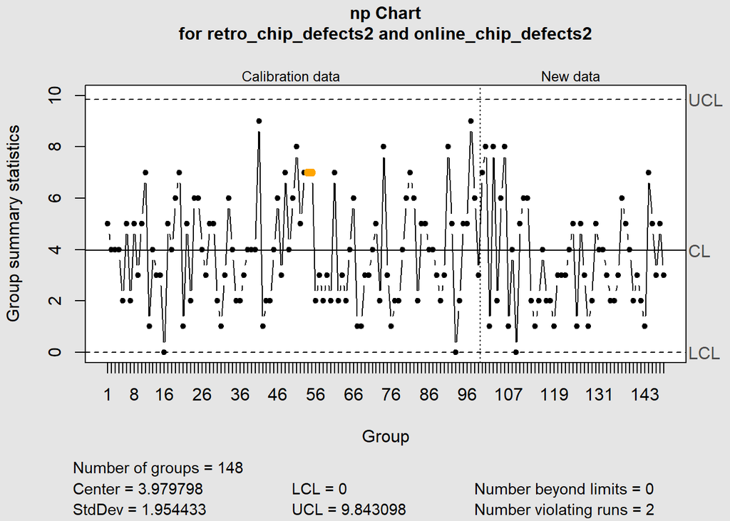

```
## List of 15
##  $ call        : language qcc(data = retro_chip_defects2, type = "np", sizes = length(retro_chip_defects2),      limits = c(0, 9.843098), n| __truncated__ ...
##  $ type        : chr "np"
##  $ data.name   : chr "retro_chip_defects2"
##  $ data        : int [1:99, 1] 5 4 4 4 2 5 2 5 3 5 ...
##   ..- attr(*, "dimnames")=List of 2
##  $ statistics  : Named int [1:99] 5 4 4 4 2 5 2 5 3 5 ...
##   ..- attr(*, "names")= chr [1:99] "1" "2" "3" "4" ...
##  $ sizes       : int [1:99] 99 99 99 99 99 99 99 99 99 99 ...
##  $ center      : num 3.98
##  $ std.dev     : num 1.95
##  $ newstats    : Named int [1:49] 7 8 1 8 2 6 8 1 4 0 ...
##   ..- attr(*, "names")= chr [1:49] "100" "101" "102" "103" ...
##  $ newdata     : int [1:49, 1] 7 8 1 8 2 6 8 1 4 0 ...
##  $ newsizes    : int [1:49] 49 49 49 49 49 49 49 49 49 49 ...
##  $ newdata.name: chr "online_chip_defects2"
##  $ nsigmas     : num 3
##  $ limits      : num [1, 1:2] 0 9.84
##   ..- attr(*, "dimnames")=List of 2
##  $ violations  :List of 2
##  - attr(*, "class")= chr "qcc"
```

```r
online_chip_defects2<-online_chip_defects<-online_chip_defects[online_chip_defects<=9.843098 & online_chip_defects>=0] #remove datapoints outside of control limits

qcc(data=retro_chip_defects2,sizes=length(retro_chip_defects2),type="np", newdata = online_chip_defects2, newsizes = length(online_chip_defects2), ylim=c(0,10), limits = c(0, 9.843098)) #NP chart with restrospective data as calibration with refined online data as new data
```

A standalone NP chart with online defect detection data was used to understand the data without comparing to the retrospective defect detection data. There was one group in the online chip defect data that was out of control and thus removed. Then, the online defect detection data was compared to respective data control limits, where there were less overall defects. In the end, there were two violating runs and no groups were out of control